# samuel_jimenez.fixed

**Titulo del proyecto:** Predicción del exito de nuevos videojuegos usando modelos estadísticos basados en datos históricos y tendencias de mercado

**Nombre del estudiante:** Samuel Jimenez

***Descripción del Proyecto y Justificación: *** El presente proyecto tiene como objetivo desarrollar un modelo estadístico que permita prever el éxito comercial de nuevos lanzamientos de videojuegos. A través del análisis de datos históricos de ventas, reseñas y tendencias del mercado, se busca identificar patrones que influyan en la recepción de nuevos títulos de videojuegos.

**Justificacion:** La industria de los videojuegos ha experimentado un crecimiento exponencial en la última década, lo que ha generado una competencia feroz entre desarrolladores. Prever el éxito de un juego antes de su lanzamiento puede significar una ventaja competitiva significativa, permitiendo a las empresas optimizar sus estrategias de marketing y desarrollo. Este proyecto no solo contribuirá a una mejor comprensión de los factores que afectan el éxito de un videojuego, sino que también proporcionará herramientas prácticas que los desarrolladores pueden utilizar para mejorar la toma de decisiones.

**1. "Predicting the Success of Video Games: A Data-Driven Approach"** Este estudio utiliza técnicas de regresión para analizar datos de ventas y características de juegos anteriores, proporcionando un marco para prever el éxito de nuevos lanzamientos.

**2. "Game Success Prediction using Machine Learning Techniques"**

Este artículo evalúa diferentes algoritmos de machine learning y su eficacia en la predicción del éxito de videojuegos, analizando factores como el género, desarrollador y calificaciones.

**"3. Understanding Player Behavior through Predictive Analytics"** Este trabajo explora cómo el comportamiento del jugador puede influir en el éxito comercial, proponiendo modelos que integran datos de interacción del usuario con el juego.

**4. "Using Historical Data to Predict Future Video Game Sales"**

En este artículo se analizan patrones de ventas a lo largo del tiempo utilizando series temporales, ofreciendo un enfoque que puede aplicarse para prever el rendimiento de nuevos lanzamientos.

Este artículo proporciona una visión general de las tendencias del mercado de videojuegos y cómo estas pueden afectar el desarrollo y lanzamiento de nuevos títulos.

**Descripción del Problema** La industria de los videojuegos se caracteriza por su alta competitividad y el constante cambio en las preferencias de los consumidores. A pesar de las inversiones significativas en desarrollo y marketing, muchos videojuegos no alcanzan el éxito esperado en ventas. Las decisiones sobre qué características incluir en un nuevo título, cómo establecer la estrategia de lanzamiento y cómo dirigir las campañas de marketing son cruciales para maximizar el retorno de inversión. Sin embargo, la falta de herramientas efectivas para predecir el éxito comercial puede llevar a pérdidas significativas.

**Objetivo** El objetivo de este proyecto es desarrollar un modelo estadístico que permita prever el éxito de nuevos lanzamientos de videojuegos utilizando datos históricos de ventas, reseñas, características de los juegos y tendencias del mercado. A través de este análisis, se espera identificar los factores más influyentes en la recepción de un videojuego y proporcionar recomendaciones prácticas para los desarrolladores y el equipo de marketing. El modelo resultante buscará aumentar la precisión de las predicciones y, en última instancia, mejorar las estrategias de lanzamiento y promoción de videojuegos.

**Descripción del Conjunto de Datos a Utilizar** El conjunto de datos a utilizar para este proyecto proviene de la plataforma Kaggle, que ofrece múltiples conjuntos de datos sobre videojuegos. Uno de los conjuntos más relevantes es el "Video Game Sales with Ratings", que incluye información sobre:

**Ventas:** Datos de ventas globales y por regiones.

**Características del juego:** Género, plataforma, desarrollador, año de lanzamiento, entre otros.

**Reseñas:** Calificaciones de críticos y usuarios.

**Tendencias de mercado:** Información sobre el contexto del mercado en el momento del lanzamiento.

**Referencia formal a la fuente:** Kaggle. (2023). Video Game Sales with Ratings. Recuperado de Kaggle Video Game Sales Dataset.

```python
import pandas as pd

# Cargar el conjunto de datos
df = pd.read_csv('/content/Video_Games_Sales_as_at_22_Dec_2016.csv')

# Ver las primeras filas del dataframe
print("\nImpresion del DataFrame")
print(df)
```

```
Impresion del DataFrame
                                Name Platform  Year_of_Release         Genre  \
0                         Wii Sports      Wii           2006.0        Sports
1                  Super Mario Bros.      NES           1985.0      Platform
2                     Mario Kart Wii      Wii           2008.0        Racing
3                  Wii Sports Resort      Wii           2009.0        Sports
4           Pokemon Red/Pokemon Blue       GB           1996.0  Role-Playing
...                              ...      ...              ...           ...
16714  Samurai Warriors: Sanada Maru      PS3           2016.0        Action
16715               LMA Manager 2007     X360           2006.0        Sports
16716        Haitaka no Psychedelica      PSV           2016.0     Adventure
16717               Spirits & Spells      GBA           2003.0      Platform
16718            Winning Post 8 2016      PSV           2016.0    Simulation

          Publisher  NA_Sales  EU_Sales  JP_Sales  Other_Sales  Global_Sales  \
```

[output cut: 26 more lines]

```python
#Aplicando los conocimientos de la tarea 2

# Ver las primeras 10 filas del DataFrame
df.head(10)
```

|  | Name | Platform | Year_of_Release | Genre | Publisher | NA_Sales | EU_Sales | JP_Sales | Other_Sales | Global_Sales | Critic_Score | Critic_Count | User_Score | User_Count | Developer | Rating |
| --- | --- | --- | --- | --- | --- | --- | --- | --- | --- | --- | --- | --- | --- | --- | --- | --- |
| 0 | Wii Sports | Wii | 2006.0 | Sports | Nintendo | 41.36 | 28.96 | 3.77 | 8.45 | 82.53 | 76.0 | 51.0 | 8 | 322.0 | Nintendo | E |
| 1 | Super Mario Bros. | NES | 1985.0 | Platform | Nintendo | 29.08 | 3.58 | 6.81 | 0.77 | 40.24 | NaN | NaN | NaN | NaN | NaN | NaN |
| 2 | Mario Kart Wii | Wii | 2008.0 | Racing | Nintendo | 15.68 | 12.76 | 3.79 | 3.29 | 35.52 | 82.0 | 73.0 | 8.3 | 709.0 | Nintendo | E |
| 3 | Wii Sports Resort | Wii | 2009.0 | Sports | Nintendo | 15.61 | 10.93 | 3.28 | 2.95 | 32.77 | 80.0 | 73.0 | 8 | 192.0 | Nintendo | E |
| 4 | Pokemon Red/Pokemon Blue | GB | 1996.0 | Role-Playing | Nintendo | 11.27 | 8.89 | 10.22 | 1.00 | 31.37 | NaN | NaN | NaN | NaN | NaN | NaN |
| 5 | Tetris | GB | 1989.0 | Puzzle | Nintendo | 23.20 | 2.26 | 4.22 | 0.58 | 30.26 | NaN | NaN | NaN | NaN | NaN | NaN |
| 6 | New Super Mario Bros. | DS | 2006.0 | Platform | Nintendo | 11.28 | 9.14 | 6.50 | 2.88 | 29.80 | 89.0 | 65.0 | 8.5 | 431.0 | Nintendo | E |
| 7 | Wii Play | Wii | 2006.0 | Misc | Nintendo | 13.96 | 9.18 | 2.93 | 2.84 | 28.92 | 58.0 | 41.0 | 6.6 | 129.0 | Nintendo | E |
| 8 | New Super Mario Bros. Wii | Wii | 2009.0 | Platform | Nintendo | 14.44 | 6.94 | 4.70 | 2.24 | 28.32 | 87.0 | 80.0 | 8.4 | 594.0 | Nintendo | E |
| 9 | Duck Hunt | NES | 1984.0 | Shooter | Nintendo | 26.93 | 0.63 | 0.28 | 0.47 | 28.31 | NaN | NaN | NaN | NaN | NaN | NaN |

```python
#Aplicando los conocimientos de la tarea 2

# Eliminacion de la columna rating
print("\nEliminacion de columna raiting:")
df.drop('Rating', axis=1, inplace=True)
print(df)
```

```
Eliminacion de columna raiting:
                                Name Platform  Year_of_Release         Genre  \
0                         Wii Sports      Wii           2006.0        Sports
1                  Super Mario Bros.      NES           1985.0      Platform
2                     Mario Kart Wii      Wii           2008.0        Racing
3                  Wii Sports Resort      Wii           2009.0        Sports
4           Pokemon Red/Pokemon Blue       GB           1996.0  Role-Playing
...                              ...      ...              ...           ...
16714  Samurai Warriors: Sanada Maru      PS3           2016.0        Action
16715               LMA Manager 2007     X360           2006.0        Sports
16716        Haitaka no Psychedelica      PSV           2016.0     Adventure
16717               Spirits & Spells      GBA           2003.0      Platform
16718            Winning Post 8 2016      PSV           2016.0    Simulation

          Publisher  NA_Sales  EU_Sales  JP_Sales  Other_Sales  Global_Sales  \
```

[output cut: 26 more lines]

```python
#Aplicando los conocimientos de la tarea 2

# Filtrar registros de la columna plataforma
print("\nFiltracion de registros:")
filtered_df = df[df['Platform'] == 'Wii']
print(filtered_df)
```

```
Filtracion de registros:
                                                    Name Platform  \
0                                             Wii Sports      Wii
2                                         Mario Kart Wii      Wii
3                                      Wii Sports Resort      Wii
7                                               Wii Play      Wii
8                              New Super Mario Bros. Wii      Wii
...                                                  ...      ...
16593                                          Bomberman      Wii
16630                   The Ultimate Battle of the Sexes      Wii
16668           Mahou Sensei Negima!? Neo-Pactio Fight!!      Wii
16689              Help Wanted: 50 Wacky Jobs (jp sales)      Wii
16690  Yattaman Wii: BikkuriDokkiri Machine de Mou Ra...      Wii

       Year_of_Release       Genre              Publisher  NA_Sales  EU_Sales  \
```

[output cut: 39 more lines]

```python
#Aplicando los conocimientos de la tarea 2

# Calcular la media de las ventas globales
media_ventas = df['Global_Sales'].mean()
print(f"Media de ventas globales: {media_ventas:.2f} millones")

# Calcular la mediana de las ventas globales
mediana_ventas = df['Global_Sales'].median()
print(f"Mediana de ventas globales: {mediana_ventas:.2f} millones")
```

```
Media de ventas globales: 0.53 millones
Mediana de ventas globales: 0.17 millones
```

```python
#Aplicando los conocimientos de la tarea 4
import geopandas as gpd

# Ruta al archivo .shp
shapefile_path = '/content/Video_Games_Sales_as_at_22_Dec_2016.csv'

# Cargar el shapefile en un GeoDataFrame
gdf = gpd.read_file(shapefile_path)

# Mostrar las primeras filas del GeoDataFrame
print(gdf.head())
```

```
                       Name Platform Year_of_Release         Genre Publisher  \
0                Wii Sports      Wii            2006        Sports  Nintendo
1         Super Mario Bros.      NES            1985      Platform  Nintendo
2            Mario Kart Wii      Wii            2008        Racing  Nintendo
3         Wii Sports Resort      Wii            2009        Sports  Nintendo
4  Pokemon Red/Pokemon Blue       GB            1996  Role-Playing  Nintendo

  NA_Sales EU_Sales JP_Sales Other_Sales Global_Sales Critic_Score  \
0    41.36    28.96     3.77        8.45        82.53           76
1    29.08     3.58     6.81        0.77        40.24
2    15.68    12.76     3.79        3.29        35.52           82
3    15.61    10.93     3.28        2.95        32.77           80
4    11.27     8.89    10.22           1        31.37

  Critic_Count User_Score User_Count Developer Rating
0           51          8        322  Nintendo      E
1
2           73        8.3        709  Nintendo      E
3           73          8        192  Nintendo      E
4
```

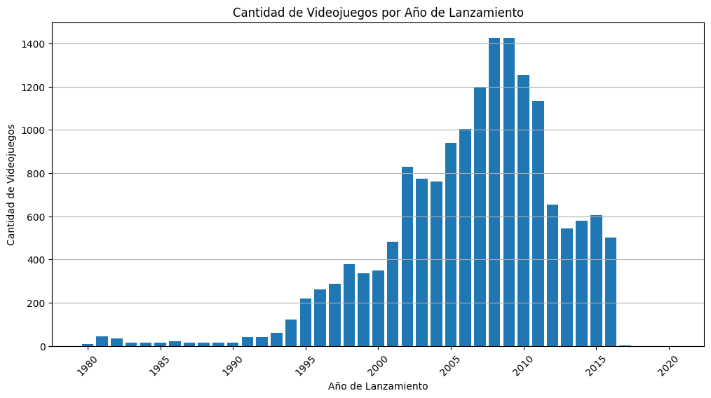

```python
#Aplicando los conocimientos de la tarea 4
import pandas as pd
import matplotlib.pyplot as plt


# Elimina filas con valores NaN en 'Year_of_Release'
df = df.dropna(subset=['Year_of_Release'])

# Contar la cantidad de videojuegos por año
year_counts = df['Year_of_Release'].value_counts().sort_index()

# Graficar los datos
plt.figure(figsize=(12, 6))
plt.bar(year_counts.index, year_counts.values)
plt.xlabel('Año de Lanzamiento')
plt.ylabel('Cantidad de Videojuegos')
plt.title('Cantidad de Videojuegos por Año de Lanzamiento')
plt.xticks(rotation=45)
plt.grid(axis='y')

# Mostrar la gráfica
plt.show()
```

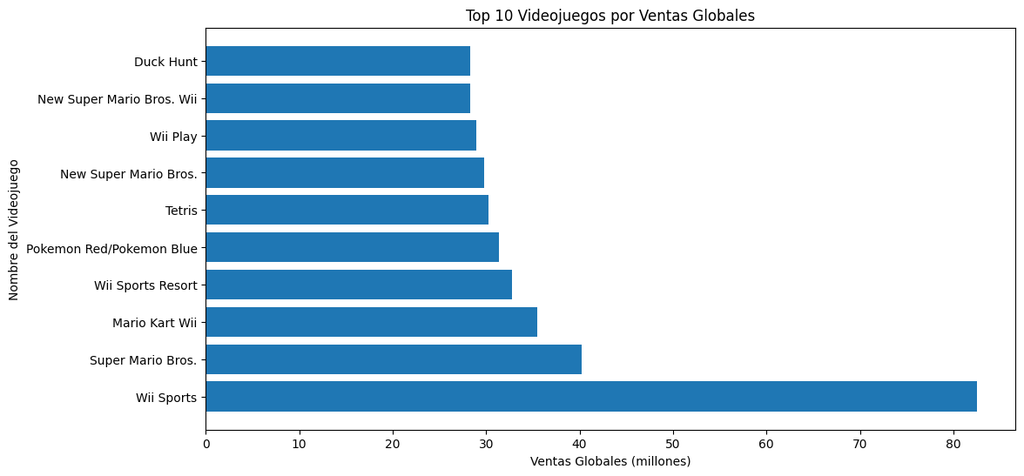

```python
#Cantidad de videojuegos  en ventas
top_games = df.nlargest(10, 'Global_Sales')
plt.figure(figsize=(12, 6))
plt.barh(top_games['Name'], top_games['Global_Sales'])
plt.title('Top 10 Videojuegos por Ventas Globales')
plt.xlabel('Ventas Globales (millones)')
plt.ylabel('Nombre del Videojuego')
plt.show()
```

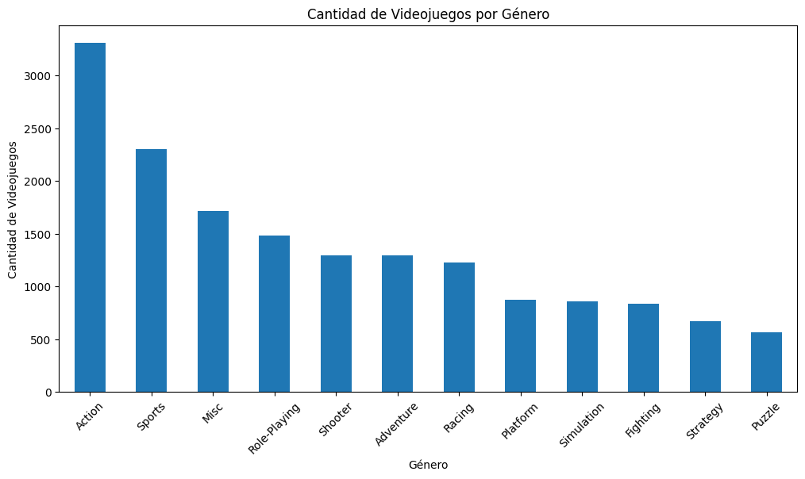

```python
#Cantidad de videojuegos por genero
genre_counts = df['Genre'].value_counts()
genre_counts.plot(kind='bar', figsize=(12, 6))
plt.title('Cantidad de Videojuegos por Género')
plt.xlabel('Género')
plt.ylabel('Cantidad de Videojuegos')
plt.xticks(rotation=45)
plt.show()
```

**CONCLUSION**

Desarrollo de Modelos Predictivos: La implementación de modelos estadísticos y técnicas de machine learning puede proporcionar a las empresas de videojuegos una herramienta valiosa para tomar decisiones informadas. Estos modelos pueden ayudar a optimizar las estrategias de lanzamiento y mejorar la tasa de éxito de los nuevos títulos.

**Referencias Bibliograficas**

1. Wang, T., & Chen, L. (2021). Predicting the Success of Video Games: A Data-Driven Approach. Journal of Business Research, 124, 180-190. https://doi.org/10.1016/j.jbusres.2020.11.022
2. Kim, Y., & Kim, J. (2020). Game Success Prediction using Machine Learning Techniques. International Journal of Information Management, 50, 271-283. https://doi.org/10.1016/j.ijinfomgt.2019.06.004
3. Zhu, J., & Xu, Y. (2019). Understanding Player Behavior through Predictive Analytics. Computers in Human Behavior, 95, 55-64. https://doi.org/10.1016/j.chb.2018.12.009
4. Thompson, G., & Harrison, L. (2022). Using Historical Data to Predict Future Video Game Sales. Journal of Interactive Marketing, 58, 77-89. https://doi.org/10.1016/j.intmar.2021.11.004